# Exploratory Breast Cancer Diagnostic Data Analysis in Python

Author

Akash Bhardwaj

Published

July 16, 2026

## Project objective

This educational project demonstrates an exploratory data analysis and introductory machine-learning workflow in Python using the Breast Cancer Wisconsin (Diagnostic) dataset.

The workflow includes data-quality checks, descriptive statistics, visualisation, train/test splitting, feature scaling, logistic regression, and classification evaluation.

## Dataset

The Breast Cancer Wisconsin (Diagnostic) dataset was loaded through `scikit-learn`.

- Total samples: 569
- Benign samples: 357
- Malignant samples: 212
- Numeric diagnostic features: 30
- Missing values: 0
- Duplicate rows: 0

The dataset contains measurements derived from digitised images of fine-needle aspirates of breast masses. It is a historic public dataset for educational use and must not be used for diagnosis, clinical decision-making, or medical advice.

## Data-quality assessment

A reusable Python script checked the processed dataset for row and column counts, missing values, duplicate rows, and diagnostic-class counts.

The checks found 569 rows, 32 columns, no missing values, and no duplicate rows.

## Exploratory data analysis

### Diagnosis class distribution

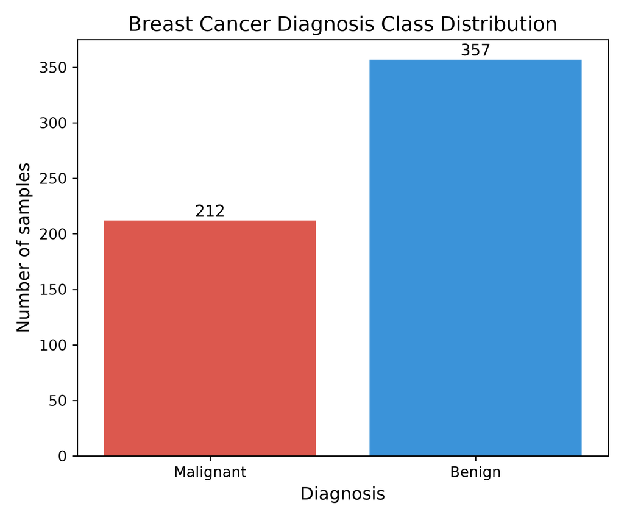

The dataset contains more benign samples than malignant samples.

### Key diagnostic-feature distributions

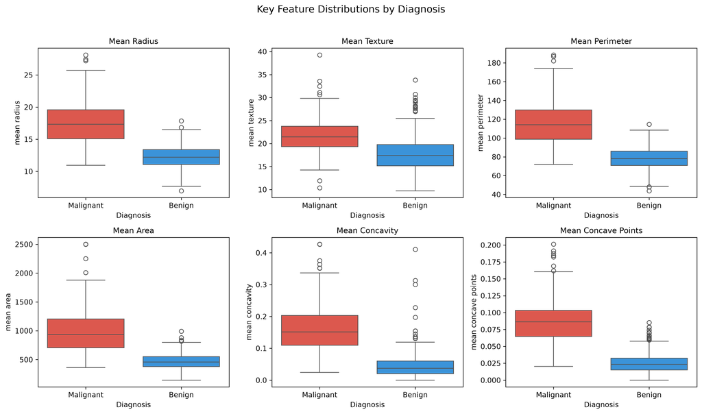

Several diagnostic features, including mean radius, perimeter, area, concavity, and concave points, showed higher values among malignant samples in this dataset.

### Correlation of mean diagnostic features

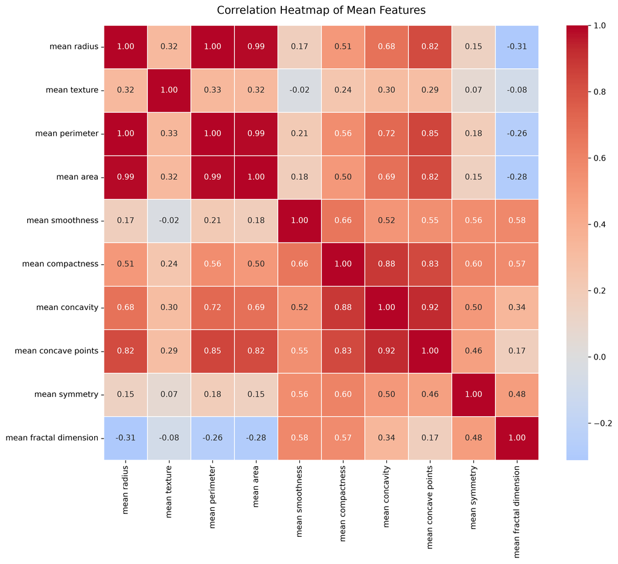

Several size-related features are strongly correlated. For example, mean radius, mean perimeter, and mean area measure related geometric properties and therefore should not be interpreted as independent signals.

### Mean radius and mean concavity

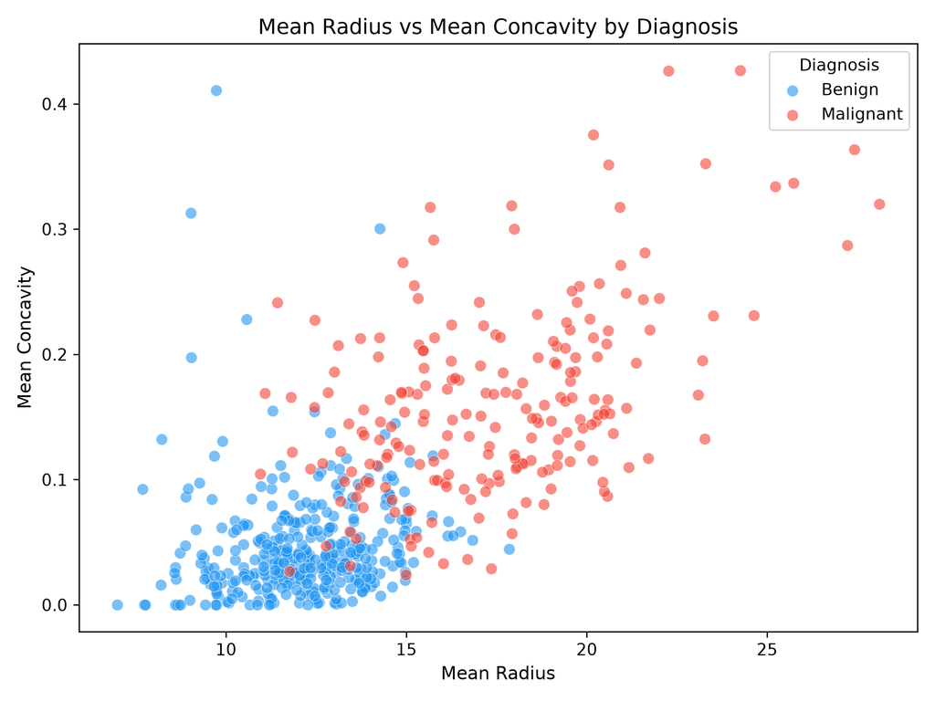

The scatter plot shows broad separation between diagnostic classes, although overlap remains between some samples.